# Sampling Project

Bank Loan Data

TMRB

2024-03-31

# *Agenda*

- *Introduction*
- *Data Set Description*
- *Exploratory Data Analysis*
- *Stratification*
- *Random Sampling*
- *Graphs*
- *Discussion*
- *Conclusion*
- *REFs*

# *Introduction*

- The U.S. Small Business Administration (SBA) helps small businesses and entrepreneurs achieve the american dream by its estimation.
- It was created in 1953 and is a cabinet level agency that provides counselling capital and contracting expertise to small business.
- It is the U.S. only go-to for resources and advocacy for small bussiness.
- Its mission statement stated plainly on its webpage is to helps Americans start, grow, and build resilient businesses.
- A data set comprising businesses just like that was explored here, where sampling methods were employed. Some recommendations regarding those methods may follow.

# *Data Set Description*

- The name of the data set is National SBA (Small Business Administration).
- It is described as census type data.
- It was contained in 9 csv files eight of which held 100,000 observations each, with the ninth holding 99164 observations.
- The data sets were combined into one data set called loan, with 899,164 observations total. There are 28 variables in loan. t
- The source of the data set is expressed to be from the United States Small Business Administration.
  - A description of the data set, taken from its origin, states that “this data set is…provides historical data from 1987 through 2014…[for loans]…that was guaranteed to some degree by the SBA.
- Included is a variable [MIS_Status] which indicates if the loan was paid in full or defaulted/charged off. Below should be a printout of the structure of the data set.

```
'data.frame':   899164 obs. of  28 variables:
 $ X                : int  1 2 3 4 5 6 7 8 9 10 ...
 $ LoanNr_ChkDgt    : num  1e+09 1e+09 1e+09 1e+09 1e+09 ...
 $ Name             : chr  "ABC HOBBYCRAFT" "LANDMARK BAR & GRILLE (THE)" "WHITLOCK DDS, TODD M." "BIG BUCKS PAWN & JEWELRY, LLC" ...
 $ City             : chr  "EVANSVILLE" "NEW PARIS" "BLOOMINGTON" "BROKEN ARROW" ...
 $ State            : chr  "IN" "IN" "IN" "OK" ...
 $ Zip              : int  47711 46526 47401 74012 32801 6062 7083 34491 32456 6073 ...
 $ Bank             : chr  "FIFTH THIRD BANK" "1ST SOURCE BANK" "GRANT COUNTY STATE BANK" "1ST NATL BK & TR CO OF BROKEN" ...
 $ BankState        : chr  "OH" "IN" "IN" "OK" ...
 $ NAICS            : int  451120 722410 621210 0 0 332721 0 811118 721310 0 ...
 $ ApprovalDate     : chr  "28-Feb-97" "28-Feb-97" "28-Feb-97" "28-Feb-97" ...
 $ ApprovalFY       : chr  "1997" "1997" "1997" "1997" ...
 $ Term             : int  84 60 180 60 240 120 45 84 297 84 ...
 $ NoEmp            : int  4 2 7 2 14 19 45 1 2 3 ...
 $ NewExist         : int  2 2 1 1 1 1 2 2 2 2 ...
 $ CreateJob        : int  0 0 0 0 7 0 0 0 0 0 ...
 $ RetainedJob      : int  0 0 0 0 7 0 0 0 0 0 ...
 $ FranchiseCode    : int  1 1 1 1 1 1 0 1 1 1 ...
 $ UrbanRural       : int  0 0 0 0 0 0 0 0 0 0 ...
 $ RevLineCr        : chr  "N" "N" "N" "N" ...
 $ LowDoc           : chr  "Y" "Y" "N" "Y" ...
 $ ChgOffDate       : chr  "" "" "" "" ...
 $ DisbursementDate : chr  "28-Feb-99" "31-May-97" "31-Dec-97" "30-Jun-97" ...
 $ DisbursementGross: chr  "$60,000.00 " "$40,000.00 " "$287,000.00 " "$35,000.00 " ...
 $ BalanceGross     : chr  "$0.00 " "$0.00 " "$0.00 " "$0.00 " ...
 $ MIS_Status       : chr  "P I F" "P I F" "P I F" "P I F" ...
 $ ChgOffPrinGr     : chr  "$0.00 " "$0.00 " "$0.00 " "$0.00 " ...
 $ GrAppv           : chr  "$60,000.00 " "$40,000.00 " "$287,000.00 " "$35,000.00 " ...
 $ SBA_Appv         : chr  "$48,000.00 " "$32,000.00 " "$215,250.00 " "$28,000.00 " ...
```

[figure not shown]

LoanData-description

# *Exploratory Data Analysis*

- Bellow are two tables that contain the proportions and frequencies of the values in the MIS_Status variable in the data set.
- The MIS_Status has been expressed to indicate default status.
- In the first table, it may be seen that there are three types of values for the variable:
  - CHGOFF
  - PIF
  - empty character value.
    - The empty character value is assumed to represent missing values.
    - It represents .0022 of the values for MIS_Status.
- The second table demonstrates the same information as the first table, except the missing values has been remove.
- Notice that the frequencies of CHGOFF and PIF do not change however their proportions do.

# *MIS_Status*

MIS_Status Before

| Value | FREQ | PROP |
| --- | --- | --- |
|  | 1997 | 0.0022210 |
| CHGOFF | 157558 | 0.1752272 |
| P I F | 739609 | 0.8225518 |

MIS_Status After

| Value | FREQ | PROP |
| --- | --- | --- |
| CHGOFF | 157558 | 0.1756172 |
| P I F | 739609 | 0.8243828 |

# *Stratification (1/3)*

- According to the North American Industry Classification System, “…(NAICS) is the standard used by Federal statistical agencies in classifying business establishments for the purpose of collecting, analyzing, and publishing statistical data related to the U.S. business economy.”
- Below is a proportion/frequency table for the North America Industry Classification System (NAICS) Codes.
- Above that table is table of some the values for the NAICS variable.
  - It may be clear that these values vary from one another.
  - However, the system codifies them by their first two digits.
  - The proportion/frequency table holds proportions and frequencies of those codes after the values within the NAICS variable were combined with the NAICS codification.
- These NAICS codes were used to stratify the data set.
- Those subsets were then sampled from.

# *Stratification (2/3)*

NAICS PRE-Combination

| Name | NAICS |
| --- | --- |
| GOMEZ’S TAQUITOS EXPRESS | 0 |
| EUROPEAN TRADITIONS | 442110 |
| AUTOCHEM INC | 422690 |
| Andrews Chiropractic, P.C. | 621310 |
| PRIMARY PREP OF ORLANDO INC | 624410 |
| Andrzej Baksik | 236118 |
| Timbuktu’s Bar & Grill | 722110 |
| PRESTIGE COFFEE SERVICE | 0 |
| RKR Transpotation, Inc. | 484110 |
| TRUFFLES GRILLE & WINE BAR LLC | 722110 |

NAICS PROP/FREQ

| Value | FREQ | PROP |
| --- | --- | --- |
| 0 | 201667 | 0.2247820 |
| 11 | 8995 | 0.0100260 |
| 21 | 1851 | 0.0020632 |
| 22 | 662 | 0.0007379 |
| 23 | 66492 | 0.0741133 |
| 31-33 | 67903 | 0.0756860 |
| 42 | 48673 | 0.0542519 |
| 44-45 | 126975 | 0.1415288 |
| 48-49 | 22408 | 0.0249764 |
| 51 | 11362 | 0.0126643 |
| 52 | 9470 | 0.0105554 |
| 53 | 13588 | 0.0151455 |
| 54 | 67922 | 0.0757072 |
| 55 | 256 | 0.0002853 |
| 56 | 32529 | 0.0362575 |
| 61 | 6401 | 0.0071347 |
| 62 | 55264 | 0.0615983 |
| 71 | 14616 | 0.0162913 |
| 72 | 67511 | 0.0752491 |
| 81 | 72395 | 0.0806929 |
| 92 | 227 | 0.0002530 |

NAICS POST-Combination

| Name | NAICS |
| --- | --- |
| GOMEZ’S TAQUITOS EXPRESS | 0 |
| EUROPEAN TRADITIONS | 44-45 |
| AUTOCHEM INC | 42 |
| Andrews Chiropractic, P.C. | 62 |
| PRIMARY PREP OF ORLANDO INC | 62 |
| Andrzej Baksik | 23 |
| Timbuktu’s Bar & Grill | 72 |
| PRESTIGE COFFEE SERVICE | 0 |
| RKR Transpotation, Inc. | 48-49 |
| TRUFFLES GRILLE & WINE BAR LLC | 72 |

# *Stratification (3/3)*

Here is an image that relates the NAICS codes to the industries that they codify.

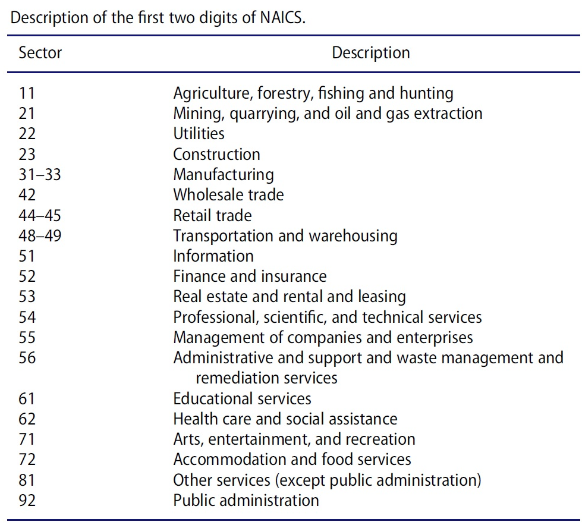

List of all industries using the first two digits of the NAICS code

# *Default Rates*

- Below is table of the default rates for the different industries that recieved loans.
  - NAICS represents their codifications
  - The status CHGOFF indicates default
  - And The rate may be gleaned on the far right

Default Rates by NAICS

| NAICS | Status | Count | Total | Rate |
| --- | --- | --- | --- | --- |
| 0 | CHGOFF | 16799 | 201667 | 0.0833 |
| 11 | CHGOFF | 812 | 8995 | 0.0903 |
| 21 | CHGOFF | 157 | 1851 | 0.0848 |
| 22 | CHGOFF | 94 | 662 | 0.1420 |
| 23 | CHGOFF | 15463 | 66492 | 0.2326 |
| 31-33 | CHGOFF | 10438 | 67903 | 0.1537 |
| 42 | CHGOFF | 9480 | 48673 | 0.1948 |
| 44-45 | CHGOFF | 28868 | 126975 | 0.2274 |
| 48-49 | CHGOFF | 5939 | 22408 | 0.2650 |
| 51 | CHGOFF | 2821 | 11362 | 0.2483 |
| 52 | CHGOFF | 2692 | 9470 | 0.2843 |
| 53 | CHGOFF | 3904 | 13588 | 0.2873 |
| 54 | CHGOFF | 12957 | 67922 | 0.1908 |
| 55 | CHGOFF | 26 | 256 | 0.1016 |
| 56 | CHGOFF | 7661 | 32529 | 0.2355 |
| 61 | CHGOFF | 1552 | 6401 | 0.2425 |
| 62 | CHGOFF | 5736 | 55264 | 0.1038 |
| 71 | CHGOFF | 3013 | 14616 | 0.2061 |
| 72 | CHGOFF | 14882 | 67511 | 0.2204 |
| 81 | CHGOFF | 14229 | 72395 | 0.1965 |
| 92 | CHGOFF | 35 | 227 | 0.1542 |

# *Random Sampling*

NAICS Counts: Proportion

| NAICS | Count | Total |
| --- | --- | --- |
| 0 | 45332 | 201667 |
| 11 | 91 | 8995 |
| 21 | 4 | 1851 |
| 22 | 1 | 662 |
| 23 | 4928 | 66492 |
| 31-33 | 5140 | 67903 |
| 42 | 2641 | 48673 |
| 44-45 | 17971 | 126975 |
| 48-49 | 560 | 22408 |
| 51 | 144 | 11362 |
| 52 | 100 | 9470 |
| 53 | 206 | 13588 |
| 54 | 5143 | 67922 |
| 55 | 1 | 256 |
| 56 | 1180 | 32529 |
| 61 | 46 | 6401 |
| 62 | 3405 | 55264 |
| 71 | 239 | 14616 |
| 72 | 5081 | 67511 |
| 81 | 5842 | 72395 |
| 92 | 1 | 227 |

NAICS Counts: 10%

| NAICS | Count | Total |
| --- | --- | --- |
| 0 | 20167 | 201667 |
| 11 | 900 | 8995 |
| 21 | 186 | 1851 |
| 22 | 67 | 662 |
| 23 | 6650 | 66492 |
| 31-33 | 6791 | 67903 |
| 42 | 4868 | 48673 |
| 44-45 | 12698 | 126975 |
| 48-49 | 2241 | 22408 |
| 51 | 1137 | 11362 |
| 52 | 947 | 9470 |
| 53 | 1359 | 13588 |
| 54 | 6793 | 67922 |
| 55 | 26 | 256 |
| 56 | 3253 | 32529 |
| 61 | 641 | 6401 |
| 62 | 5527 | 55264 |
| 71 | 1462 | 14616 |
| 72 | 6752 | 67511 |
| 81 | 7240 | 72395 |
| 92 | 23 | 227 |

# *Simple Random Sample*

- Here simple random sampling was conducted on the different categories of NAICS codes.
- The data set should of had a sample of varying number of observations taken at random without replacement.
- A tables follows.
  - There are six columns.
    - The first should show the Industry codes.
    - The next should show the default status,
    - then the amount of those statuses within the sample.
    - The industry level samples should follow under Totals.
    - Then the sample’s default rate and industry’s default rates should round out the far right.

SRS: Default Rates by NAICS

| NAICS | Status | Count | Totals | SRate | PRate |
| --- | --- | --- | --- | --- | --- |
| 0 | CHGOFF | 1679 | 20167 | 0.0833 | 0.0833 |
| 11 | CHGOFF | 90 | 900 | 0.1000 | 0.0903 |
| 21 | CHGOFF | 14 | 186 | 0.0753 | 0.0848 |
| 22 | CHGOFF | 13 | 67 | 0.1940 | 0.1420 |
| 23 | CHGOFF | 1531 | 6650 | 0.2302 | 0.2326 |
| 31-33 | CHGOFF | 1081 | 6791 | 0.1592 | 0.1537 |
| 42 | CHGOFF | 944 | 4868 | 0.1939 | 0.1948 |
| 44-45 | CHGOFF | 2860 | 12698 | 0.2252 | 0.2274 |
| 48-49 | CHGOFF | 587 | 2241 | 0.2619 | 0.2650 |
| 51 | CHGOFF | 290 | 1137 | 0.2551 | 0.2483 |
| 52 | CHGOFF | 284 | 947 | 0.2999 | 0.2843 |
| 53 | CHGOFF | 395 | 1359 | 0.2907 | 0.2873 |
| 54 | CHGOFF | 1337 | 6793 | 0.1968 | 0.1908 |
| 55 | CHGOFF | 2 | 26 | 0.0769 | 0.1016 |
| 56 | CHGOFF | 758 | 3253 | 0.2330 | 0.2355 |
| 61 | CHGOFF | 149 | 641 | 0.2324 | 0.2425 |
| 62 | CHGOFF | 608 | 5527 | 0.1100 | 0.1038 |
| 71 | CHGOFF | 311 | 1462 | 0.2127 | 0.2061 |
| 72 | CHGOFF | 1459 | 6752 | 0.2161 | 0.2204 |
| 81 | CHGOFF | 1423 | 7240 | 0.1965 | 0.1965 |
| 92 | CHGOFF | 1 | 23 | 0.0435 | 0.1542 |

# *Systemic Simple Random Sample*

- Here systemic simple random sampling was conducted.
- The data sets should of had varying amounts of observations taken with the first observation being found at random and all other observations being some constant distance from that observation.
- A tables follows.
  - There are six columns.
    - The first should show the Industry codes.
    - The next should show the default status,
    - then the amount of those statuses within the sample.
    - The industry level samples should follow under Totals.
    - Then the sample’s default rate and industry’s default rates should round out the far right.

SSRS: Default Rates by NAICS

| NAICS | Status | Count | Totals | SRate | PRate |
| --- | --- | --- | --- | --- | --- |
| 0 | CHGOFF | 909 | 15319 | 0.0593 | 0.0833 |
| 11 | CHGOFF | 73 | 817 | 0.0894 | 0.0903 |
| 21 | CHGOFF | 4 | 54 | 0.0741 | 0.0848 |
| 22 | CHGOFF | 13 | 61 | 0.2131 | 0.1420 |
| 23 | CHGOFF | 1244 | 5569 | 0.2234 | 0.2326 |
| 31-33 | CHGOFF | 268 | 2486 | 0.1078 | 0.1537 |
| 42 | CHGOFF | 25 | 218 | 0.1147 | 0.1948 |
| 44-45 | CHGOFF | 460 | 2611 | 0.1762 | 0.2274 |
| 48-49 | CHGOFF | 492 | 1968 | 0.2500 | 0.2650 |
| 51 | CHGOFF | 22 | 78 | 0.2821 | 0.2483 |
| 52 | CHGOFF | 1 | 9 | 0.1111 | 0.2843 |
| 53 | CHGOFF | 284 | 1098 | 0.2587 | 0.2873 |
| 54 | CHGOFF | 423 | 4056 | 0.1043 | 0.1908 |
| 55 | CHGOFF | 2 | 10 | 0.2000 | 0.1016 |
| 56 | CHGOFF | 206 | 1534 | 0.1343 | 0.2355 |
| 61 | CHGOFF | 36 | 186 | 0.1935 | 0.2425 |
| 62 | CHGOFF | 212 | 3184 | 0.0666 | 0.1038 |
| 71 | CHGOFF | 66 | 441 | 0.1497 | 0.2061 |
| 72 | CHGOFF | 368 | 2163 | 0.1701 | 0.2204 |
| 81 | CHGOFF | 192 | 1366 | 0.1406 | 0.1965 |

# *Stratified Sample*

- Here stratified sampling was conducted.
- The data set should of had a samples for each category taken at 10%.
- Each of the Industries were subset on the variable UrbanRural.
  - its values were expressed to be 0 = undefined, 1 = urban, and 2 = rural.
  - The variable was not given a description outside of that.
  - It was believed that these designations refer to where the business that received these loans is located.
  - One might imagine then that some industries are represented in some settings better than others.
- Some tables follow.
  - There are seven columns.
  - The first should show the Industry codes.
  - The next should show the UrbanRural status and default status, then the amount of those statuses within the sample.
  - The industry level samples should follow under Totals.
  - Then the sample’s default rate and industry’s default rates should round out the far right.
- One may note that there are entries missing in the first and last table.
  - Inspecting the Sample Default Rates table for SRAT0, entries for 55 and 92 are missing and in the Industry Default Rates table for SRAT0 55 is missing.
  - Like wise one may notice that in the Sample Default Rates table for SRAT2 that entries for 55 are missing.

# *Stratified Sample Table (1/3)*

SRAT0: Sample Default Rates by NAICS

| NAICS | UrbanRural | Status | Count | Totals | SRate | PRate |
| --- | --- | --- | --- | --- | --- | --- |
| 0 | 0 | CHGOFF | 1447 | 17878 | 0.0809 | 0.0787 |
| 11 | 0 | CHGOFF | 20 | 434 | 0.0461 | 0.0395 |
| 21 | 0 | CHGOFF | 1 | 67 | 0.0149 | 0.0403 |
| 22 | 0 | CHGOFF | 1 | 21 | 0.0476 | 0.0526 |
| 23 | 0 | CHGOFF | 64 | 1358 | 0.0471 | 0.0570 |
| 31-33 | 0 | CHGOFF | 113 | 1852 | 0.0610 | 0.0546 |
| 42 | 0 | CHGOFF | 69 | 1339 | 0.0515 | 0.0521 |
| 44-45 | 0 | CHGOFF | 233 | 2914 | 0.0800 | 0.0807 |
| 48-49 | 0 | CHGOFF | 12 | 158 | 0.0759 | 0.0839 |
| 51 | 0 | CHGOFF | 16 | 194 | 0.0825 | 0.0883 |
| 52 | 0 | CHGOFF | 6 | 41 | 0.1463 | 0.1144 |
| 53 | 0 | CHGOFF | 19 | 174 | 0.1092 | 0.0811 |
| 54 | 0 | CHGOFF | 73 | 1271 | 0.0574 | 0.0472 |
| 56 | 0 | CHGOFF | 28 | 346 | 0.0809 | 0.0789 |
| 61 | 0 | CHGOFF | 4 | 30 | 0.1333 | 0.1365 |
| 62 | 0 | CHGOFF | 56 | 1598 | 0.0350 | 0.0397 |
| 71 | 0 | CHGOFF | 26 | 339 | 0.0767 | 0.0720 |
| 72 | 0 | CHGOFF | 40 | 432 | 0.0926 | 0.1096 |
| 81 | 0 | CHGOFF | 103 | 1822 | 0.0565 | 0.0604 |

SRAT0: Industry Default Rates by NAICS

| NAICS | UrbanRural | Status | Count | Totals | PRate |
| --- | --- | --- | --- | --- | --- |
| 0 | 0 | CHGOFF | 14077 | 178771 | 0.0787 |
| 0 | 0 | P I F | 164694 | 178771 | 0.9213 |
| 11 | 0 | CHGOFF | 171 | 4334 | 0.0395 |
| 11 | 0 | P I F | 4163 | 4334 | 0.9605 |
| 21 | 0 | CHGOFF | 27 | 670 | 0.0403 |
| 21 | 0 | P I F | 643 | 670 | 0.9597 |
| 22 | 0 | CHGOFF | 11 | 209 | 0.0526 |
| 22 | 0 | P I F | 198 | 209 | 0.9474 |
| 23 | 0 | CHGOFF | 774 | 13573 | 0.0570 |
| 23 | 0 | P I F | 12799 | 13573 | 0.9430 |
| 31-33 | 0 | CHGOFF | 1011 | 18518 | 0.0546 |
| 31-33 | 0 | P I F | 17507 | 18518 | 0.9454 |
| 42 | 0 | CHGOFF | 697 | 13390 | 0.0521 |
| 42 | 0 | P I F | 12693 | 13390 | 0.9479 |
| 44-45 | 0 | CHGOFF | 2353 | 29140 | 0.0807 |
| 44-45 | 0 | P I F | 26787 | 29140 | 0.9193 |
| 48-49 | 0 | CHGOFF | 132 | 1573 | 0.0839 |
| 48-49 | 0 | P I F | 1441 | 1573 | 0.9161 |
| 51 | 0 | CHGOFF | 171 | 1936 | 0.0883 |
| 51 | 0 | P I F | 1765 | 1936 | 0.9117 |
| 52 | 0 | CHGOFF | 46 | 402 | 0.1144 |
| 52 | 0 | P I F | 356 | 402 | 0.8856 |
| 53 | 0 | CHGOFF | 141 | 1739 | 0.0811 |
| 53 | 0 | P I F | 1598 | 1739 | 0.9189 |
| 54 | 0 | CHGOFF | 600 | 12707 | 0.0472 |
| 54 | 0 | P I F | 12107 | 12707 | 0.9528 |
| 56 | 0 | CHGOFF | 273 | 3458 | 0.0789 |
| 56 | 0 | P I F | 3185 | 3458 | 0.9211 |
| 61 | 0 | CHGOFF | 40 | 293 | 0.1365 |
| 61 | 0 | P I F | 253 | 293 | 0.8635 |
| 62 | 0 | CHGOFF | 634 | 15975 | 0.0397 |
| 62 | 0 | P I F | 15341 | 15975 | 0.9603 |
| 71 | 0 | CHGOFF | 244 | 3388 | 0.0720 |
| 71 | 0 | P I F | 3144 | 3388 | 0.9280 |
| 72 | 0 | CHGOFF | 473 | 4314 | 0.1096 |
| 72 | 0 | P I F | 3841 | 4314 | 0.8904 |
| 81 | 0 | CHGOFF | 1100 | 18219 | 0.0604 |
| 81 | 0 | P I F | 17119 | 18219 | 0.9396 |
| 92 | 0 | CHGOFF | 3 | 128 | 0.0234 |
| 92 | 0 | P I F | 125 | 128 | 0.9766 |

# *Stratified Sample Table (2/3)*

SRAT1: Sample Default Rates by NAICS

| NAICS | UrbanRural | Status | Count | Totals | SRate | PRate |
| --- | --- | --- | --- | --- | --- | --- |
| 0 | 1 | CHGOFF | 225 | 1924 | 0.1169 | 0.1205 |
| 11 | 1 | CHGOFF | 24 | 148 | 0.1622 | 0.1936 |
| 21 | 1 | CHGOFF | 10 | 61 | 0.1639 | 0.1301 |
| 22 | 1 | CHGOFF | 9 | 32 | 0.2812 | 0.2045 |
| 23 | 1 | CHGOFF | 1237 | 4162 | 0.2972 | 0.2899 |
| 31-33 | 1 | CHGOFF | 796 | 3911 | 0.2035 | 0.2004 |
| 42 | 1 | CHGOFF | 765 | 3063 | 0.2498 | 0.2564 |
| 44-45 | 1 | CHGOFF | 2160 | 7923 | 0.2726 | 0.2822 |
| 48-49 | 1 | CHGOFF | 512 | 1581 | 0.3238 | 0.3057 |
| 51 | 1 | CHGOFF | 237 | 818 | 0.2897 | 0.2905 |
| 52 | 1 | CHGOFF | 230 | 796 | 0.2889 | 0.2980 |
| 53 | 1 | CHGOFF | 354 | 986 | 0.3590 | 0.3318 |
| 54 | 1 | CHGOFF | 1124 | 4860 | 0.2313 | 0.2276 |
| 55 | 1 | CHGOFF | 2 | 15 | 0.1333 | 0.1633 |
| 56 | 1 | CHGOFF | 645 | 2427 | 0.2658 | 0.2677 |
| 61 | 1 | CHGOFF | 144 | 527 | 0.2732 | 0.2542 |
| 62 | 1 | CHGOFF | 443 | 3287 | 0.1348 | 0.1354 |
| 71 | 1 | CHGOFF | 255 | 876 | 0.2911 | 0.2653 |
| 72 | 1 | CHGOFF | 1191 | 4988 | 0.2388 | 0.2403 |
| 81 | 1 | CHGOFF | 1165 | 4544 | 0.2564 | 0.2522 |
| 92 | 1 | CHGOFF | 2 | 9 | 0.2222 | 0.3218 |

SRAT1: Industry Default Rates by NAICS

| NAICS | UrbanRural | Status | Count | Totals | PRate |
| --- | --- | --- | --- | --- | --- |
| 0 | 1 | CHGOFF | 2318 | 19232 | 0.1205 |
| 0 | 1 | P I F | 16914 | 19232 | 0.8795 |
| 11 | 1 | CHGOFF | 286 | 1477 | 0.1936 |
| 11 | 1 | P I F | 1191 | 1477 | 0.8064 |
| 21 | 1 | CHGOFF | 79 | 607 | 0.1301 |
| 21 | 1 | P I F | 528 | 607 | 0.8699 |
| 22 | 1 | CHGOFF | 64 | 313 | 0.2045 |
| 22 | 1 | P I F | 249 | 313 | 0.7955 |
| 23 | 1 | CHGOFF | 12066 | 41615 | 0.2899 |
| 23 | 1 | P I F | 29549 | 41615 | 0.7101 |
| 31-33 | 1 | CHGOFF | 7838 | 39105 | 0.2004 |
| 31-33 | 1 | P I F | 31267 | 39105 | 0.7996 |
| 42 | 1 | CHGOFF | 7851 | 30623 | 0.2564 |
| 42 | 1 | P I F | 22772 | 30623 | 0.7436 |
| 44-45 | 1 | CHGOFF | 22357 | 79224 | 0.2822 |
| 44-45 | 1 | P I F | 56867 | 79224 | 0.7178 |
| 48-49 | 1 | CHGOFF | 4831 | 15805 | 0.3057 |
| 48-49 | 1 | P I F | 10974 | 15805 | 0.6943 |
| 51 | 1 | CHGOFF | 2376 | 8180 | 0.2905 |
| 51 | 1 | P I F | 5804 | 8180 | 0.7095 |
| 52 | 1 | CHGOFF | 2370 | 7952 | 0.2980 |
| 52 | 1 | P I F | 5582 | 7952 | 0.7020 |
| 53 | 1 | CHGOFF | 3272 | 9860 | 0.3318 |
| 53 | 1 | P I F | 6588 | 9860 | 0.6682 |
| 54 | 1 | CHGOFF | 11058 | 48595 | 0.2276 |
| 54 | 1 | P I F | 37537 | 48595 | 0.7724 |
| 55 | 1 | CHGOFF | 24 | 147 | 0.1633 |
| 55 | 1 | P I F | 123 | 147 | 0.8367 |
| 56 | 1 | CHGOFF | 6495 | 24263 | 0.2677 |
| 56 | 1 | P I F | 17768 | 24263 | 0.7323 |
| 61 | 1 | CHGOFF | 1338 | 5264 | 0.2542 |
| 61 | 1 | P I F | 3926 | 5264 | 0.7458 |
| 62 | 1 | CHGOFF | 4451 | 32866 | 0.1354 |
| 62 | 1 | P I F | 28415 | 32866 | 0.8646 |
| 71 | 1 | CHGOFF | 2322 | 8754 | 0.2653 |
| 71 | 1 | P I F | 6432 | 8754 | 0.7347 |
| 72 | 1 | CHGOFF | 11986 | 49879 | 0.2403 |
| 72 | 1 | P I F | 37893 | 49879 | 0.7597 |
| 81 | 1 | CHGOFF | 11457 | 45433 | 0.2522 |
| 81 | 1 | P I F | 33976 | 45433 | 0.7478 |
| 92 | 1 | CHGOFF | 28 | 87 | 0.3218 |
| 92 | 1 | P I F | 59 | 87 | 0.6782 |

# *Stratified Sample Table (3/3)*

SRAT2: Sample Default Rates by NAICS

| NAICS | UrbanRural | Status | Count | Totals | SRate | PRate |
| --- | --- | --- | --- | --- | --- | --- |
| 0 | 2 | CHGOFF | 46 | 367 | 0.1253 | 0.1103 |
| 11 | 2 | CHGOFF | 34 | 319 | 0.1066 | 0.1115 |
| 21 | 2 | CHGOFF | 5 | 58 | 0.0862 | 0.0889 |
| 22 | 2 | CHGOFF | 1 | 14 | 0.0714 | 0.1357 |
| 23 | 2 | CHGOFF | 265 | 1131 | 0.2343 | 0.2320 |
| 31-33 | 2 | CHGOFF | 179 | 1028 | 0.1741 | 0.1546 |
| 42 | 2 | CHGOFF | 97 | 466 | 0.2082 | 0.2000 |
| 44-45 | 2 | CHGOFF | 438 | 1862 | 0.2352 | 0.2234 |
| 48-49 | 2 | CHGOFF | 104 | 503 | 0.2068 | 0.1940 |
| 51 | 2 | CHGOFF | 30 | 125 | 0.2400 | 0.2199 |
| 52 | 2 | CHGOFF | 21 | 112 | 0.1875 | 0.2473 |
| 53 | 2 | CHGOFF | 50 | 199 | 0.2513 | 0.2469 |
| 54 | 2 | CHGOFF | 107 | 662 | 0.1616 | 0.1962 |
| 56 | 2 | CHGOFF | 87 | 481 | 0.1809 | 0.1857 |
| 61 | 2 | CHGOFF | 15 | 85 | 0.1765 | 0.2062 |
| 62 | 2 | CHGOFF | 61 | 643 | 0.0949 | 0.1014 |
| 71 | 2 | CHGOFF | 47 | 248 | 0.1895 | 0.1807 |
| 72 | 2 | CHGOFF | 246 | 1332 | 0.1847 | 0.1819 |
| 81 | 2 | CHGOFF | 165 | 875 | 0.1886 | 0.1912 |
| 92 | 2 | CHGOFF | 1 | 2 | 0.5000 | 0.3333 |

SRAT2: Industry Default Rates by NAICS

| NAICS | UrbanRural | Status | Count | Totals | PRate |
| --- | --- | --- | --- | --- | --- |
| 0 | 2 | CHGOFF | 404 | 3664 | 0.1103 |
| 0 | 2 | P I F | 3260 | 3664 | 0.8897 |
| 11 | 2 | CHGOFF | 355 | 3184 | 0.1115 |
| 11 | 2 | P I F | 2829 | 3184 | 0.8885 |
| 21 | 2 | CHGOFF | 51 | 574 | 0.0889 |
| 21 | 2 | P I F | 523 | 574 | 0.9111 |
| 22 | 2 | CHGOFF | 19 | 140 | 0.1357 |
| 22 | 2 | P I F | 121 | 140 | 0.8643 |
| 23 | 2 | CHGOFF | 2623 | 11304 | 0.2320 |
| 23 | 2 | P I F | 8681 | 11304 | 0.7680 |
| 31-33 | 2 | CHGOFF | 1589 | 10280 | 0.1546 |
| 31-33 | 2 | P I F | 8691 | 10280 | 0.8454 |
| 42 | 2 | CHGOFF | 932 | 4660 | 0.2000 |
| 42 | 2 | P I F | 3728 | 4660 | 0.8000 |
| 44-45 | 2 | CHGOFF | 4158 | 18611 | 0.2234 |
| 44-45 | 2 | P I F | 14453 | 18611 | 0.7766 |
| 48-49 | 2 | CHGOFF | 976 | 5030 | 0.1940 |
| 48-49 | 2 | P I F | 4054 | 5030 | 0.8060 |
| 51 | 2 | CHGOFF | 274 | 1246 | 0.2199 |
| 51 | 2 | P I F | 972 | 1246 | 0.7801 |
| 52 | 2 | CHGOFF | 276 | 1116 | 0.2473 |
| 52 | 2 | P I F | 840 | 1116 | 0.7527 |
| 53 | 2 | CHGOFF | 491 | 1989 | 0.2469 |
| 53 | 2 | P I F | 1498 | 1989 | 0.7531 |
| 54 | 2 | CHGOFF | 1299 | 6620 | 0.1962 |
| 54 | 2 | P I F | 5321 | 6620 | 0.8038 |
| 55 | 2 | CHGOFF | 2 | 20 | 0.1000 |
| 55 | 2 | P I F | 18 | 20 | 0.9000 |
| 56 | 2 | CHGOFF | 893 | 4808 | 0.1857 |
| 56 | 2 | P I F | 3915 | 4808 | 0.8143 |
| 61 | 2 | CHGOFF | 174 | 844 | 0.2062 |
| 61 | 2 | P I F | 670 | 844 | 0.7938 |
| 62 | 2 | CHGOFF | 651 | 6423 | 0.1014 |
| 62 | 2 | P I F | 5772 | 6423 | 0.8986 |
| 71 | 2 | CHGOFF | 447 | 2474 | 0.1807 |
| 71 | 2 | P I F | 2027 | 2474 | 0.8193 |
| 72 | 2 | CHGOFF | 2423 | 13318 | 0.1819 |
| 72 | 2 | P I F | 10895 | 13318 | 0.8181 |
| 81 | 2 | CHGOFF | 1672 | 8743 | 0.1912 |
| 81 | 2 | P I F | 7071 | 8743 | 0.8088 |
| 92 | 2 | CHGOFF | 4 | 12 | 0.3333 |
| 92 | 2 | P I F | 8 | 12 | 0.6667 |

# *Graphs*

- Below are graphs that may allow one to visually compare differences in the sampling procedures.
- A legend is affixed to the upper left corner that may allow one to match the sampling procedures with the vertical bars for each graph.
- In the first graphs differences between the Industry level default rate, SRS, and Systemic SRS may be visible.
- The next three tables may demonstrate differences between stratified default rates for the UrbanRural variable and the Industry level default rate.

# *Graphs Default Rates Visual Comparison*

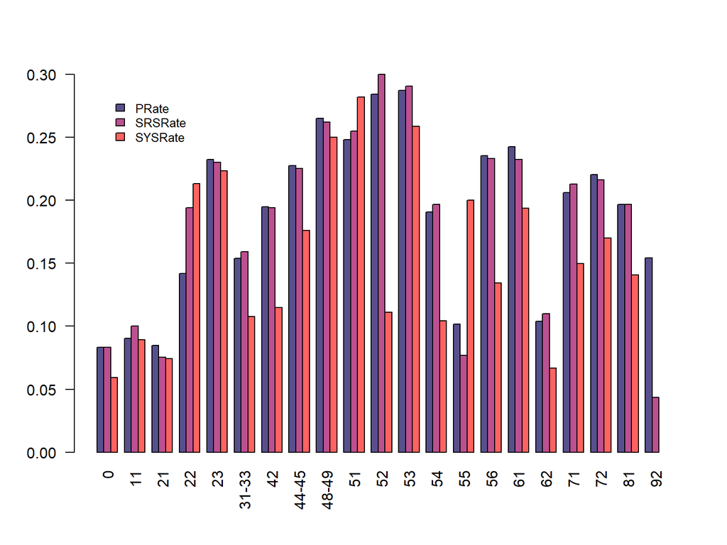

# *Graphs SRAT0 Visual Comparison*

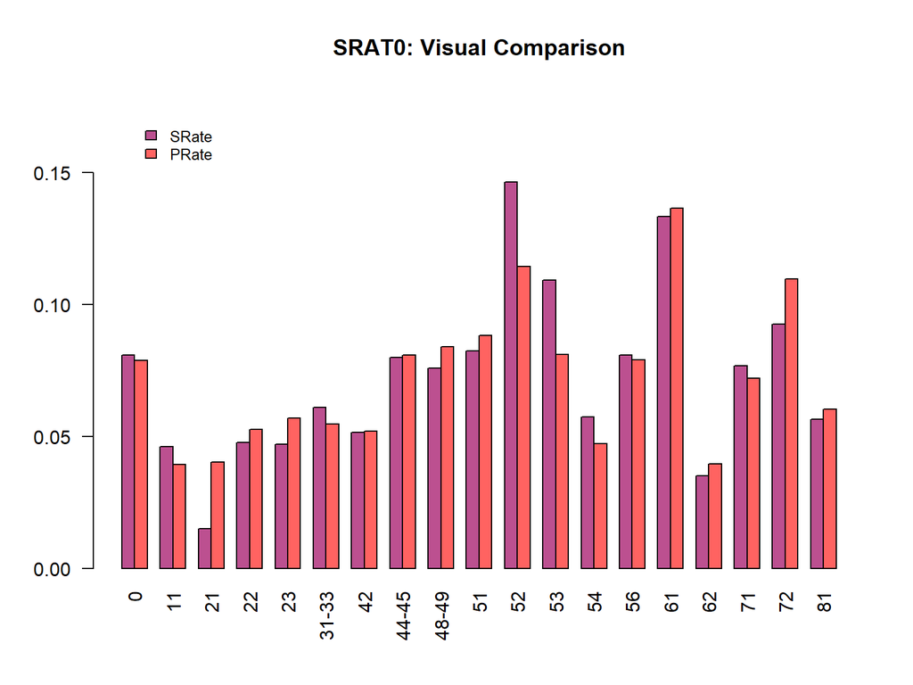

# *Graphs SRAT1 Visual Comparison*

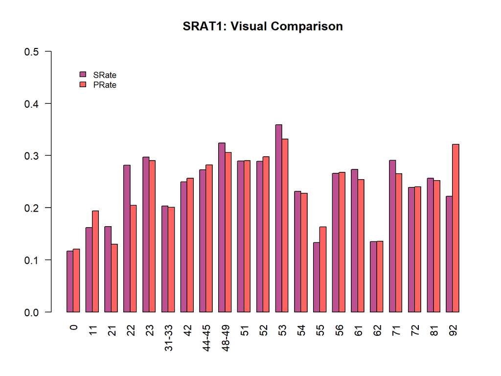

# *Graphs SRAT2 Visual Comparison*

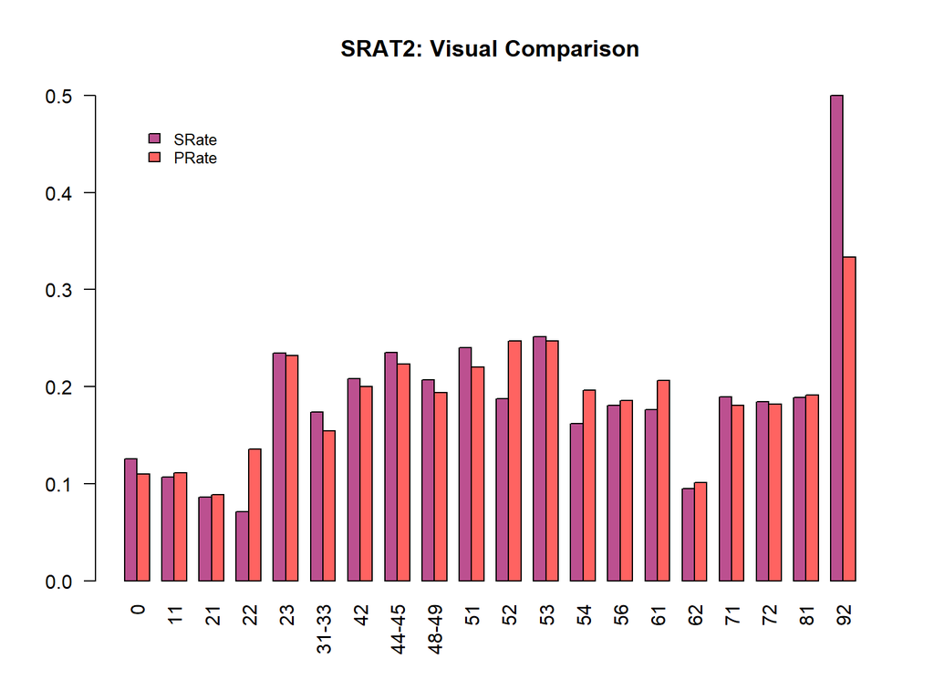

# *Discussion (1/3)*

# *Discussion (2/3)*

# *Discussion (3/3)*

- Inspecting the Sample Default Rates table for SRAT0 one may notice that entries for 55 and 92 are missing and in the Industry Default Rates table for SRAT0 55 is missing.
- Like wise one may notice that in the Sample Default Rates table for SRAT2 that entries for 55 are missing.
- One may blame the proportions of the values in the dataset for this.

# *Conclusion*

In conclusion, there is not enough information to provide a recommendation for these sampling methods. Future work may include sample size tweeks, further exploration of criteria to create a cluster variable, and understanding the discrepencies in the stratified procedure.

# *REFs*

- ,Administration, U. S. (n.d.). About SBA. Retrieved from SBA: https://www.sba.gov/about-sba
- ,United States Census Bureau. (n.d.). North American Industry Classification System - NAICS. Retrieved from Census: https://www.census.gov/naics/